# Final_project

Kasper og Konrad

2026-05-24

```r
# Chunk options: Hide code execution messages and warnings from the final report
knitr::opts_chunk$set(echo = TRUE, message = FALSE, warning = FALSE)

# 0. Check and install missing packages dynamically if necessary
required_packages <- c("tidyverse", "wbstats", "scales", "patchwork")
new_packages <- required_packages[!(required_packages %in% installed.packages()[,"Package"])]
if(length(new_packages)) install.packages(new_packages)

# 1. Load toolkits
library(tidyverse)
library(wbstats)
library(scales)
library(patchwork)
```

1.1 Data Gathering and Cleaning In this initial step, we isolate historical banana trade volumes from the UN FAOSTAT servers and cross-reference them with core development markers pulled directly via the World Bank API.

```r
# 1. Override R's download time limit to allow up to 15 minutes for the file transfer
options(timeout = 900)

# 2. Define links and paths (Fixed: Stripped Markdown wrapper formatting)
raw_url <- "https://bulks-faostat.fao.org/production/Trade_CropsLivestock_E_All_Data_(Normalized).zip"
dest_file <- "fao_trade_data.zip"

# 3. Automatically download the file natively if it doesn't exist yet
if (!file.exists(dest_file)) {
  download.file(url = raw_url, destfile = dest_file, mode = "wb")
}

# 4. Safely unzip and read the raw data into R completely intact
raw_fao_data <- read_csv(unz(dest_file, "Trade_CropsLivestock_E_All_Data_(Normalized).csv"),
                         locale = locale(encoding = "latin1"))

# 5. Extract and Clean the 3-Country baseline dataset
# Fixed: Created this explicitly so full_dataset_3ch doesn't throw a missing object error
fao_bananas_clean <- raw_fao_data %>%
  filter(
    `Area Code` %in% c(95, 89, 48),    # 95 = Honduras, 89 = Guatemala, 48 = Costa Rica
    `Item Code` == 486,               # Bananas
    `Element Code` == 5922            # Export Value (1000 USD)
  ) %>%
  mutate(banana_export_value = Value * 1000) %>%
  select(year = Year, country = Area, banana_export_value)

# Pull Prosperity Markers from World Bank API
wb_indicators <- wb_data(
  indicator = c("NY.GDP.PCAP.KD", "SP.DYN.LE00.IN"),
  country = c("GT", "HN", "CR"),
  start_date = 1961,
  end_date = 2024
) %>%
  mutate(year = as.numeric(date)) %>%
  select(year, country, gdp_pc = NY.GDP.PCAP.KD, life_exp = SP.DYN.LE00.IN)

# Merge datasets together
full_dataset_3ch <- wb_indicators %>%
  inner_join(fao_bananas_clean, by = c("year", "country"))
```

1.2 Creating Grahp

With the unified database active, we build three distinct graphical timelines using ggplot2

Panel 1 tracks raw banana export cash flows over time. Panel 2 monitors macroeconomic trajectory via purchasing capability indicators. Panel 3 tracks foundational human health progression. Rather than looking at these variables in isolation, we utilize the patchwork library to compile all three line graphs into a single, multi-tiered visual dashboard. The final consolidated layout is rendered to the screen and saved.

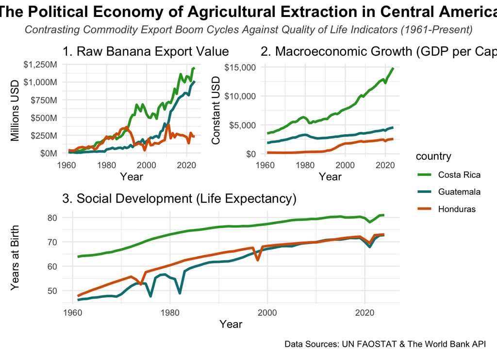

```r
# Plot 1: Raw Banana Values
p1 <- ggplot(full_dataset_3ch, aes(x = year, y = banana_export_value, color = country)) +
  geom_line(linewidth = 1.2) +
  scale_y_continuous(labels = label_dollar(scale = 1e-6, suffix = "M")) +
  scale_color_manual(values = c("Guatemala" = "#008080", "Honduras" = "#D95F02", "Costa Rica" = "#2CA02C")) +
  labs(title = "1. Raw Banana Export Value", x = "Year", y = "Millions USD") +
  theme_minimal() +
  theme(legend.position = "none")

# Plot 2: Macro-Growth GDP
p2 <- ggplot(full_dataset_3ch, aes(x = year, y = gdp_pc, color = country)) +
  geom_line(linewidth = 1.2) +
  scale_y_continuous(labels = label_dollar()) +
  scale_color_manual(values = c("Guatemala" = "#008080", "Honduras" = "#D95F02", "Costa Rica" = "#2CA02C")) +
  labs(title = "2. Macroeconomic Growth (GDP per Capita)", x = "Year", y = "Constant USD") +
  theme_minimal() +
  theme(legend.position = "none")

# Plot 3: Human Wellbeing
p3 <- ggplot(full_dataset_3ch, aes(x = year, y = life_exp, color = country)) +
  geom_line(linewidth = 1.2) +
  scale_color_manual(values = c("Guatemala" = "#008080", "Honduras" = "#D95F02", "Costa Rica" = "#2CA02C")) +
  labs(title = "3. Social Development (Life Expectancy)", x = "Year", y = "Years at Birth") +
  theme_minimal()

# Combine using patchwork
final_slide <- (p1 | p2) / p3 +
  plot_layout(guides = "collect") +
  plot_annotation(
    title = "The Political Economy of Agricultural Extraction in Central America",
    subtitle = "Contrasting Commodity Export Boom Cycles Against Quality of Life Indicators (1961-Present)",
    caption = "Data Sources: UN FAOSTAT & The World Bank API",
    theme = theme(
      plot.title = element_text(size = 16, face = "bold", hjust = 0.5),
      plot.subtitle = element_text(size = 11, face = "italic", hjust = 0.5, color = "grey30")
    )
  )

# Output plot to document
final_slide
```

```r
# Save asset
ggsave("banana_economy_dashboard.png", plot = final_slide, width = 14, height = 8.5, dpi = 300)
```

2.1 Re-filtering and 4-Way Relational Join We expand our analytical framework to include Spain (Area Code 203 / ES). Because the UN and World Bank database schemas use distinct localized naming conventions for European territories, we apply a standardized case_when transformation block. This ensures that country strings match flawlessly across both systems prior to executing our inner relational merge.

```r
fao_bananas_4ch <- raw_fao_data %>%
  filter(
    `Area Code` %in% c(95, 89, 203, 48),
    `Item Code` == 486,
    `Element Code` == 5922
  ) %>%
  mutate(
    banana_export_value = Value * 1000,
    country = case_when(
      `Area Code` == 95  ~ "Honduras",
      `Area Code` == 89  ~ "Guatemala",
      `Area Code` == 203 ~ "Spain",
      `Area Code` == 48  ~ "Costa Rica"
    )
  ) %>%
  select(year = Year, country, banana_export_value)

# Pull development markers for 4 countries
wb_indicators_4ch <- wb_data(
  indicator = c("NY.GDP.PCAP.KD", "SP.DYN.LE00.IN"),
  country = c("GT", "HN", "ES", "CR"),
  start_date = 1961,
  end_date = 2024
) %>%
  mutate(year = as.numeric(date)) %>%
  mutate(country = case_when(
    country == "Guatemala"  ~ "Guatemala",
    country == "Honduras"   ~ "Honduras",
    country == "Spain"      ~ "Spain",
    country == "Costa Rica" ~ "Costa Rica"
  )) %>%
  select(year, country, gdp_pc = NY.GDP.PCAP.KD, life_exp = SP.DYN.LE00.IN)

# Bind tables together
full_dataset_4ch <- wb_indicators_4ch %>%
  inner_join(fao_bananas_4ch, by = c("year", "country"))
```

2.2 4-Country Graph To ensure that adding a fourth nation doesn’t compromise visual readability, we declare a custom, high-contrast color palette (country_palette). We rebuild the three tracking plots using our expanded four-nation dataset. We then recombine these revised graphs. and save the output.

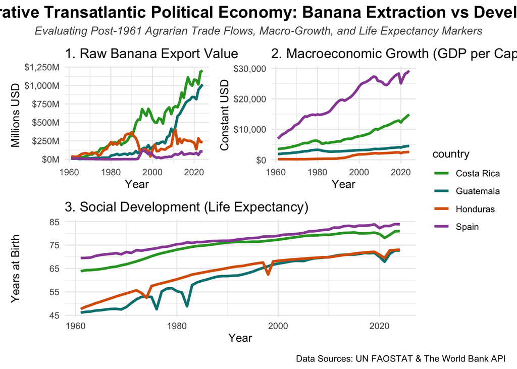

```r
# Color palette setups
country_palette <- c(
  "Guatemala"  = "#008080",
  "Honduras"   = "#D95F02",
  "Spain"      = "#984EA3",
  "Costa Rica" = "#2CA02C"
)

# Plot 1: Raw Banana Values
p1_4ch <- ggplot(full_dataset_4ch, aes(x = year, y = banana_export_value, color = country)) +
  geom_line(linewidth = 1.2) +
  scale_y_continuous(labels = label_dollar(scale = 1e-6, suffix = "M")) +
  scale_color_manual(values = country_palette) +
  labs(title = "1. Raw Banana Export Value", x = "Year", y = "Millions USD") +
  theme_minimal() +
  theme(legend.position = "none")

# Plot 2: Macro-Growth GDP per Capita
p2_4ch <- ggplot(full_dataset_4ch, aes(x = year, y = gdp_pc, color = country)) +
  geom_line(linewidth = 1.2) +
  scale_y_continuous(labels = label_dollar()) +
  scale_color_manual(values = country_palette) +
  labs(title = "2. Macroeconomic Growth (GDP per Capita)", x = "Year", y = "Constant USD") +
  theme_minimal() +
  theme(legend.position = "none")

# Plot 3: Human Wellbeing (Life Expectancy)
p3_4ch <- ggplot(full_dataset_4ch, aes(x = year, y = life_exp, color = country)) +
  geom_line(linewidth = 1.2) +
  scale_color_manual(values = country_palette) +
  labs(title = "3. Social Development (Life Expectancy)", x = "Year", y = "Years at Birth") +
  theme_minimal()

# Composite layout
final_slide_spain <- (p1_4ch | p2_4ch) / p3_4ch +
  plot_layout(guides = "collect") +
  plot_annotation(
    title = "Comparative Transatlantic Political Economy: Banana Extraction vs Development",
    subtitle = "Evaluating Post-1961 Agrarian Trade Flows, Macro-Growth, and Life Expectancy Markers",
    caption = "Data Sources: UN FAOSTAT & The World Bank API",
    theme = theme(
      plot.title = element_text(size = 16, face = "bold", hjust = 0.5),
      plot.subtitle = element_text(size = 11, face = "italic", hjust = 0.5, color = "grey30")
    )
  )

# Display
final_slide_spain
```

```r
ggsave("banana_economy_dashboard.withspain.png", plot = final_slide_spain, width = 14, height = 8.5, dpi = 300)
```

2.3 Zooming in om the timeline

To better examine the changes to the banana production of spain we zoom the graphs in to the time period of 1961-1985 and shrink the y-axis in the grahp displaing banana production.

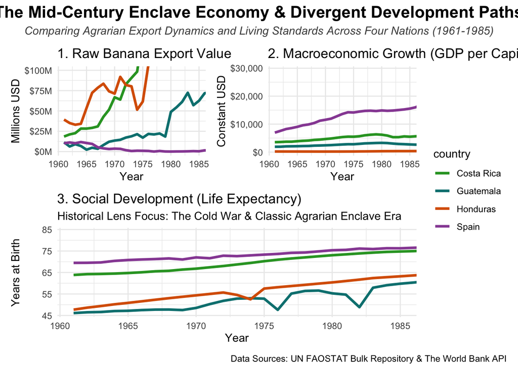

```r
# 1. Apply timeline crop and y-axis safeties
p1_zoomed <- p1_4ch + coord_cartesian(
  xlim = c(1961, 1985),
  ylim = c(0, 100e6)
)

# 2. Wealth Matrix crop
p2_zoomed <- p2_4ch + coord_cartesian(
  xlim = c(1961, 1985)
)

# 3. Social Indicator crop
p3_zoomed <- p3_4ch + coord_cartesian(
  xlim = c(1961, 1985)
) +
  labs(subtitle = "Historical Lens Focus: The Cold War & Classic Agrarian Enclave Era")

# Combined Zoomed Dashboard
final_slide_zoomed <- (p1_zoomed | p2_zoomed) / p3_zoomed +
  plot_layout(guides = "collect") +
  plot_annotation(
    title = "The Mid-Century Enclave Economy & Divergent Development Paths",
    subtitle = "Comparing Agrarian Export Dynamics and Living Standards Across Four Nations (1961-1985)",
    caption = "Data Sources: UN FAOSTAT Bulk Repository & The World Bank API",
    theme = theme(
      plot.title = element_text(size = 16, face = "bold", hjust = 0.5),
      plot.subtitle = element_text(size = 11, face = "italic", hjust = 0.5, color = "grey30"),
    )
  )

# Display inside final report
final_slide_zoomed
```

```r
ggsave("banana_economy_dashboard.4countries.1985.png", plot = final_slide_zoomed, width = 14, height = 8.5, dpi = 300)
```

3.1 To understand the ground-level impact of export-oriented farming, we expand our study to look at spatial trade-offs. We fetch live historical records from Our World in Data (OWID) to track two contrasting trends: **industrial efficiency** (monitored via banana tons produced per hectare) and **domestic food security assets** (monitored via arable hectares available per person).

Because analyzing land space in tiny fractions of a hectare can be tough to visualize, we use a `mutate` transformation to convert arable land into square meters ($1\text{ ha} = 10,000\text{ m}^2$). This scale makes the real-world impact much more intuitive. Finally, we use an inner join to merge these data frames by country and year codes, keeping our focus squarely on the 1961–2024 window.

```r
# 1. Fetch Transnational Export Data (Banana Yields)
banana_yields <- read_csv("https://ourworldindata.org/grapher/banana-yields.csv") %>%
  select(Country = Entity, Code, Year, Banana_Yield = last_col()) %>%
  filter(Country %in% c("Guatemala", "Honduras", "Costa Rica"))

# 2. Fetch Domestic Food Footprint (Arable Hectares per Person)
food_land_per_capita <- read_csv("https://ourworldindata.org/grapher/arable-land-use-per-person.csv") %>%
  select(Country = Entity, Code, Year, Hectares_Per_Capita = last_col()) %>%
  filter(Country %in% c("Guatemala", "Honduras", "Costa Rica")) %>%
  # Convert hectares to square meters for an intuitive visualization scale
  mutate(Sqm_Per_Capita = Hectares_Per_Capita * 10000)

# Blend data frames cleanly across matching historical metrics
dashboard_data <- banana_yields %>%
  inner_join(food_land_per_capita, by = c("Country", "Code", "Year")) %>%
  filter(Year >= 1961)
```

3.2 Stacking Spatial Imbalance Visualizations With our land metrics matched up, we create two stacked timeline graphs to highlight a classic economic puzzle. The Top Panel charts the rapid rise of industrial farming efficiency, tracking how banana yields skyrocketed as production grew more intense. The Bottom Panel maps a clear structural challenge: the steady decline of available arable land left for each citizen’s domestic food needs. Using patchwork, we stack these panels directly on top of each other.The finished dashboard is printed directly into this report and saved as a high-resolution file.

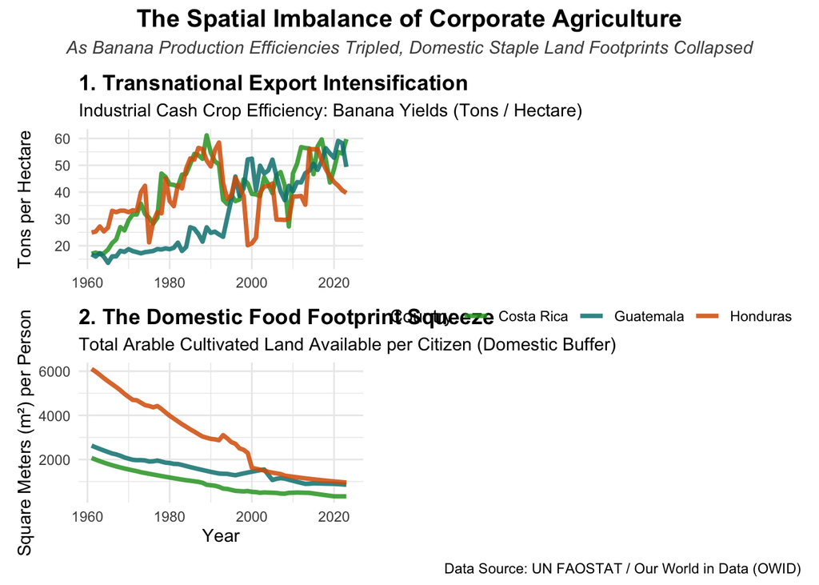

```r
# Your explicit project color template mapping
crop_colors <- c(
  "Guatemala"  = "#008080",  # Teal
  "Honduras"   = "#D95F02",  # Orange
  "Spain"      = "#984EA3",  # Purple
  "Costa Rica" = "#2CA02C"   # Green
)

# Plot 1: Transnational Industrial Efficiency (The Upper Trend)
plot_top <- ggplot(dashboard_data, aes(x = Year, y = Banana_Yield, color = Country)) +
  geom_line(linewidth = 1.3, alpha = 0.85) +
  scale_color_manual(values = crop_colors) +
  scale_x_continuous(limits = c(1961, 2024)) +
  labs(
    title = "1. Transnational Export Intensification",
    subtitle = "Industrial Cash Crop Efficiency: Banana Yields (Tons / Hectare)",
    y = "Tons per Hectare",
    x = NULL
  ) +
  theme_minimal() +
  theme(legend.position = "none", plot.title = element_text(face = "bold"))

# Plot 2: Domestic Subsistence Squeeze (The Downward Structural Trend)
plot_bottom <- ggplot(dashboard_data, aes(x = Year, y = Sqm_Per_Capita, color = Country)) +
  geom_line(linewidth = 1.3, alpha = 0.85) +
  scale_color_manual(values = crop_colors) +
  scale_x_continuous(limits = c(1961, 2024)) +
  labs(
    title = "2. The Domestic Food Footprint Squeeze",
    subtitle = "Total Arable Cultivated Land Available per Citizen (Domestic Buffer)",
    y = "Square Meters (m²) per Person",
    x = "Year"
  ) +
  theme_minimal() +
  theme(legend.position = "bottom", plot.title = element_text(face = "bold"))

# Compile stacked graphic layout using patchwork
compiled_slide <- plot_top / plot_bottom

final_dashboard <- compiled_slide +
  plot_layout(guides = "collect") +
  plot_annotation(
    title = "The Spatial Imbalance of Corporate Agriculture",
    subtitle = "As Banana Production Efficiencies Tripled, Domestic Staple Land Footprints Collapsed",
    caption = "Data Source: UN FAOSTAT / Our World in Data (OWID)",
    theme = theme(
      plot.title = element_text(size = 15, face = "bold", hjust = 0.5),
      plot.subtitle = element_text(size = 11, face = "italic", hjust = 0.5, color = "grey30")
    )
  )

# Output final render to plot window
final_dashboard
```

```r
# Save high-resolution digital image copy
ggsave(
  filename = "corporate_land_squeeze_dashboard.png",
  plot = final_dashboard,
  width = 13,
  height = 8.5,
  dpi = 300
)
```